# Clase 1

## Variables continuas

- El conjunto de valores posibles es un continuo, por ejemplo, un número real entre $0$ y $1$.
- Suelen representarse a través de una *densidad*, una función que da la probabilidad de cualquier evento como el área que define el gráfico de la función. La densidad es como un 'histograma continuo' (la cantidad de *bins* tiende a infinito).
- No se suele hablar de la probabilidad de un punto, sino de una región (la probabilidad de que $X$ esté entre $a$ y $b$).

### Ejemplos

- Distribución uniforme (continua) $X \sim U(a,b)$: Los valores posibles son los números reales entre $a$ y $b$, todos con la misma probabilidad.
- Distribucion normal $X \sim N(\mu, \sigma)$: La más conocida, los valores posibles son toda la recta real, la densidad es una *campana de Gauss*, con centro en $\mu$ y "ancho" controlado por $\sigma$. Si $n$ es grande, la binomial $B(n,p)$ se parece mucho a la normal (el limite da normal).
- Distribución Log-Normal $X \sim LogNormal(\mu, \sigma^2)$: Usada mucho en finanzas para modelar, por ejemplo, los precios de acciones, es la distribución que cumple que $log(X)$ tiene distribución normal. Su densidad es como una campana de Gauss pero "estirada" hacia la derecha.

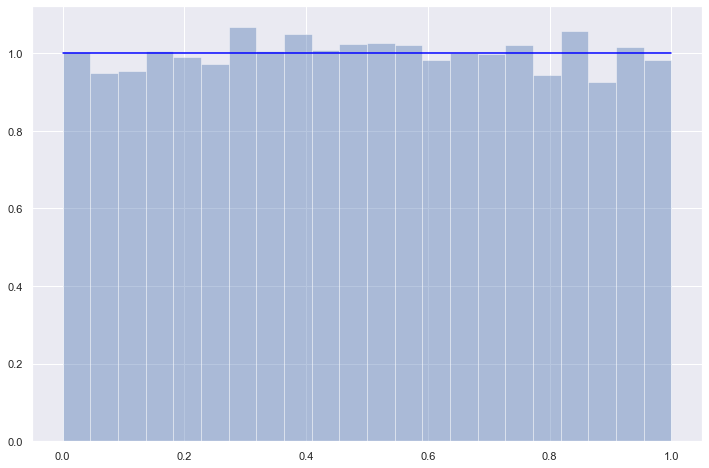

```python
x = np.linspace(0,1,1000)
plt.plot(x,stats.uniform.pdf(x),color='blue');

# 10000 samples de una uniforme (0, 1)
samples = np.random.uniform(0, 1, 10000)
sns.distplot(samples, kde=False, norm_hist=True);
```

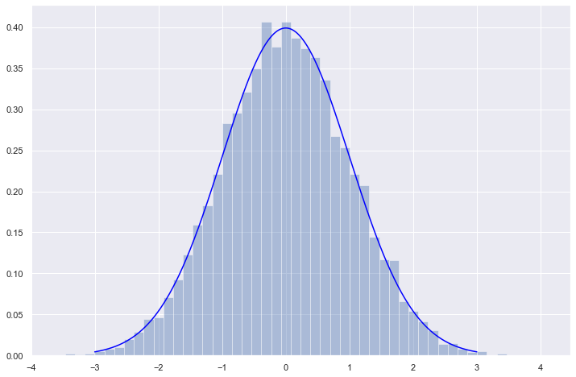

```python
# Normal (0,1)
x = np.linspace(-3, 3, 10000)
plt.plot(x, stats.norm.pdf(x), color='blue');

# 10000 samples de una normal (0, 1)
mu = 0
sigma = 1
samples = np.random.normal(mu, sigma, 10000)
sns.distplot(samples, kde=False, norm_hist=True);
```

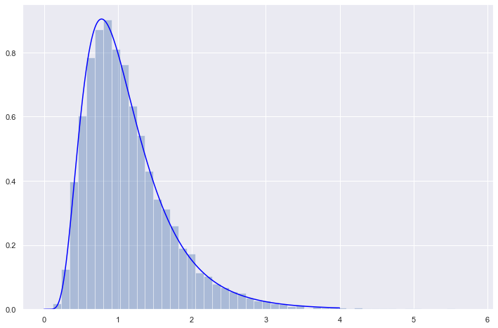

```python
# Log-Normal (0, 0.5)
sigma = 0.5

x=np.linspace(0,4,10000)
plt.plot(x,stats.lognorm.pdf(x, sigma),color='blue');

# 10000 samples de una normal (0, sigma)
samples = np.random.lognormal(0, sigma, 10000)
sns.distplot(samples, kde=False, norm_hist=True);
```